# Vaccination and Heterogeneity

### How does heterogeneity in the population impact vaccine effectiveness?

#### Random Vaccination

- How effective is random vaccination at preventing endemicity in populations with varying degrees of heterogeneity (in transmission)?
- Include a homogeneous population for comparison
- Random Vaccination = individual-based control
  - Vaccinated units are selected at random from the population
  - The exposure and transmission potential of vaccinated units is set to 0, all other units remain the same.

##### Vaccination of Heterogeneous Populations: from Lloyd-Smith *et al.* (2005)

- Individual-specific measures outperform population-wide control measures
  - Population-wide measures (e.g. social distancing) are measures which reduce the transmission potential of every unit in the population by a set factor, c. $v_c = (1-c)*v$
  - Individual-specific measures (e.g. vaccination) are interventions in which a proportion, c, of individuals have their transmission potential reduced to 0 $v_c = 0$ for vaccinated individuals $v_c = v$ for remainder of population
- Individual-specific measures increase outbreak heterogeneity, whilst population-wide measures decrease heterogeneity. A higher degree of heterogeneity promotes stochastic extinction, as shown previously.
- For both Individual-Specific, and Population-Wide control the threshold control effort for guaranteed extinction is: $c ≥ 1 - 1/R0$

### Model Parameters

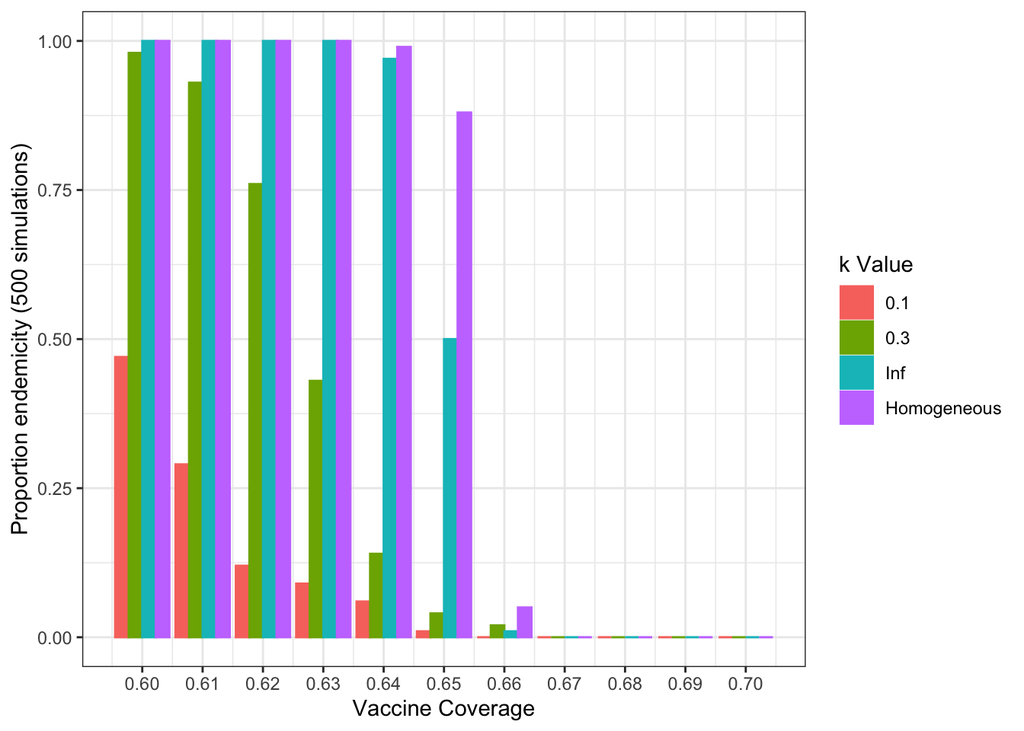

**Explanation**

- With increasing heterogeneity, extinction occurs at lower vaccination coverage levels.
- Useful metrics:
  - What is the incidence of the endemic situations?
  - What do epidemic trajectories look like, for different k values?
  - If run for many simulations, are there any scenarios where HIT does not guarantee extinction?

### Individual Epidemic Trajectories

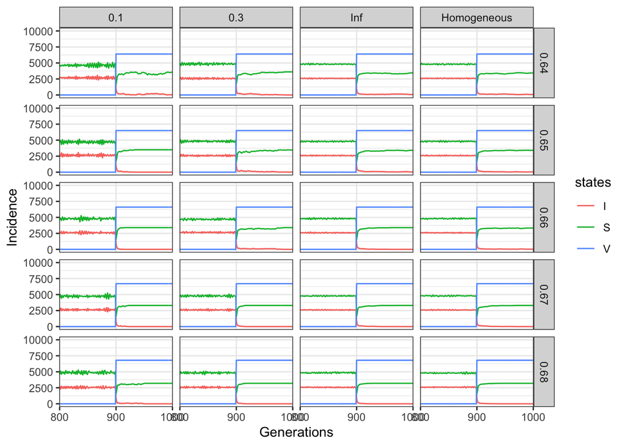

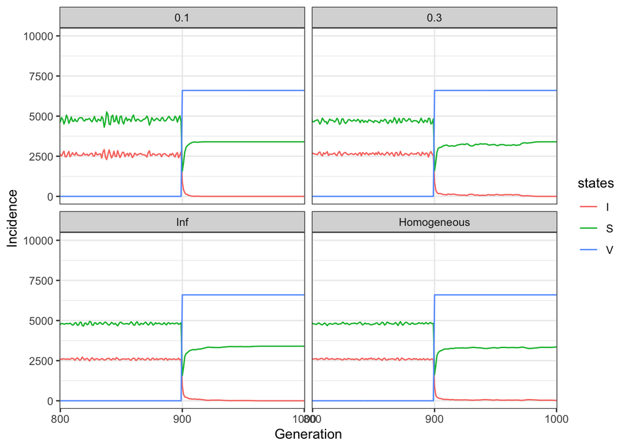

**Explanation** * Increased variation around median incidence for lower values of k, increases likelihood of stochastic extinction.